# 2023年度报告-利润分析

使用em的业绩报告数据。

## 利润

### 每年利润总和及增长

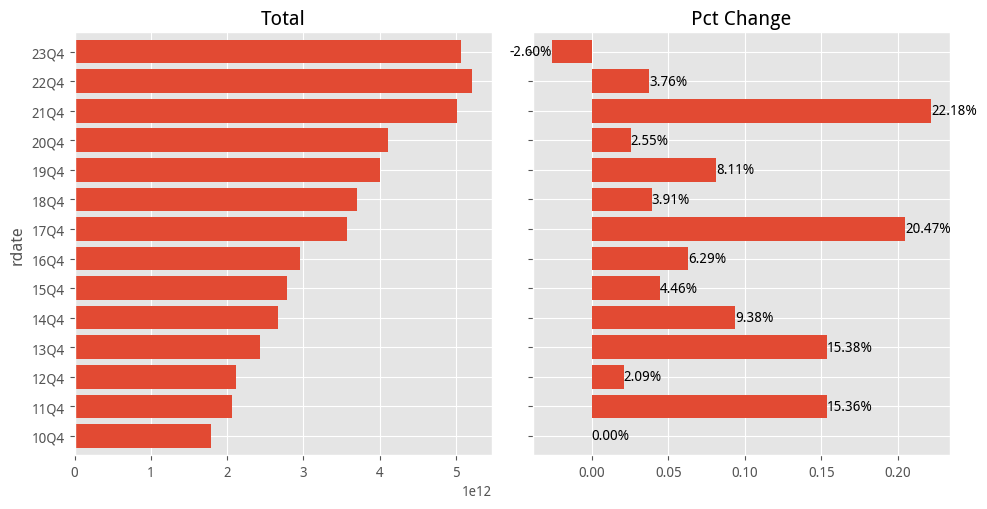

- 2023年可以说是历史性的一年了。A股市场总利润可能是历史上，至少是从2010年起出现的首次“负增长”。
- 过去的13年中，有4年实现两位数增长，最高的是2021年度，增长超过了21% 。
- 简单的计算总利润增长，包括了新发股票和已上市公司的利润增长两个因素。可以看一下剔除2010年后上市公司的影响，看2010年前上市公司的利润增长。

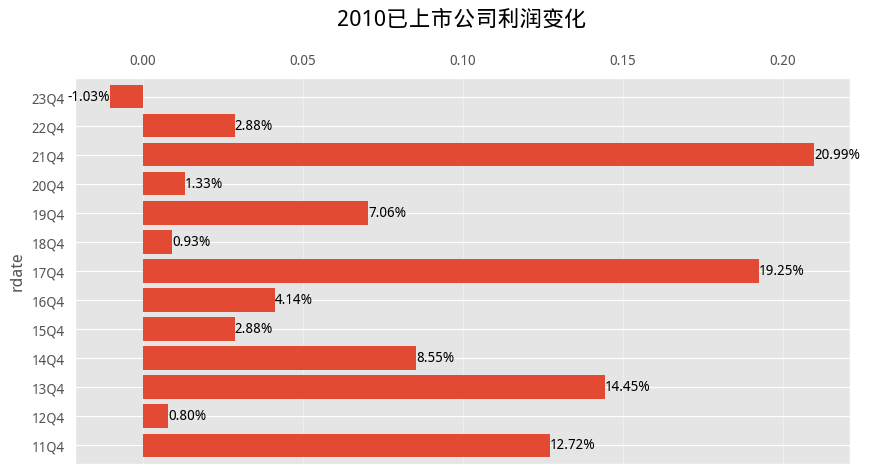

可以看出，2010年后上市公司对总利润的贡献放大了利润变化的程度。老公司的衰退程度比新公司小。

### 总体变化

- 平均利润近年首次出现下滑。利润中位数出现连续第二年下滑。利润中位数小于平均数，而且有扩大的趋势，说明利润集中化。
- 利润最大的公司，都知道是工商银行，居然利润还在增长。
- 最大亏损公司，亏损金额居然是近年来亏损最少的。

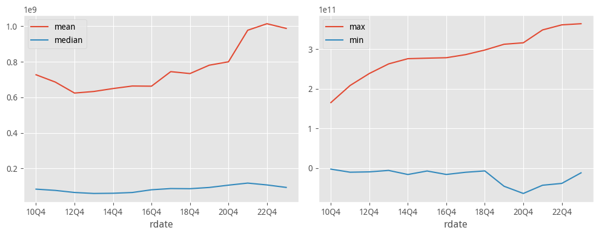

### 负值变化

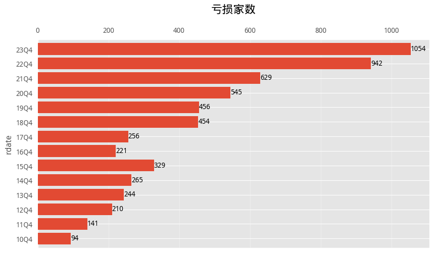

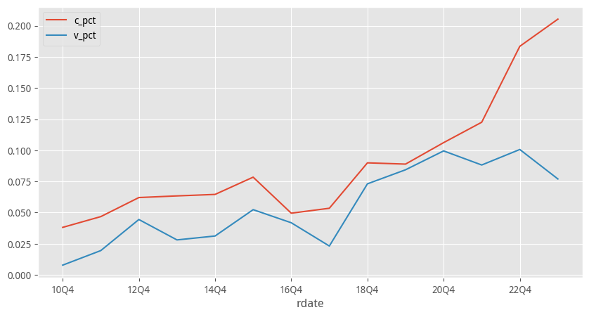

### 每年利润前20

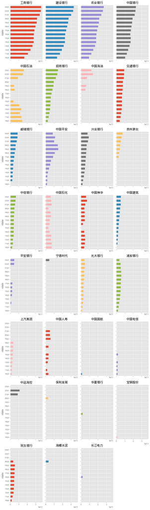

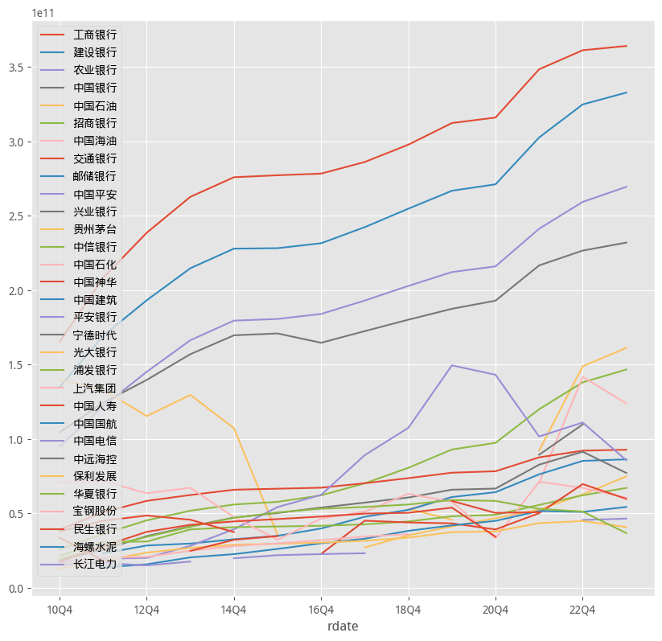

- 这些大巨头中，三桶油和中国平安的波动相对较大。

### 最近一年利润分布

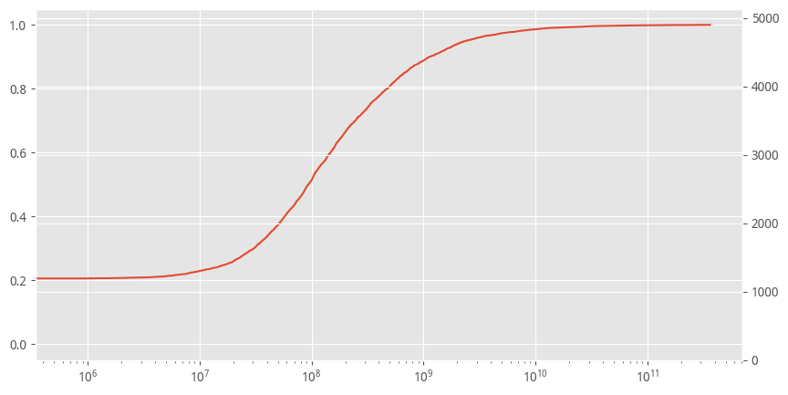

## TOP300

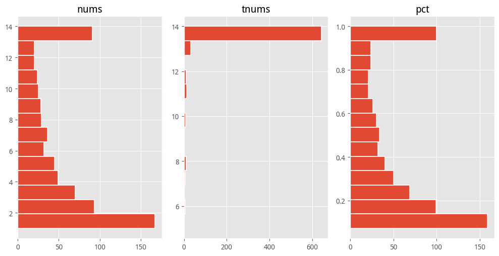

1

[工商银行](https://data.eastmoney.com/stockdata/601398.html)

2

[建设银行](https://data.eastmoney.com/stockdata/601939.html)

3

[农业银行](https://data.eastmoney.com/stockdata/601288.html)

4

[北京银行](https://data.eastmoney.com/stockdata/601169.html)

5

[宁波银行](https://data.eastmoney.com/stockdata/002142.html)

6

[中国交建](https://data.eastmoney.com/stockdata/601800.html)

7

[上海银行](https://data.eastmoney.com/stockdata/601229.html)

8

[中国太保](https://data.eastmoney.com/stockdata/601601.html)

9

[长江电力](https://data.eastmoney.com/stockdata/600900.html)

10

[华夏银行](https://data.eastmoney.com/stockdata/600015.html)

11

[中国铁建](https://data.eastmoney.com/stockdata/601186.html)

12

[上汽集团](https://data.eastmoney.com/stockdata/600104.html)

13

[美的集团](https://data.eastmoney.com/stockdata/000333.html)

14

[民生银行](https://data.eastmoney.com/stockdata/600016.html)

15

[泸州老窖](https://data.eastmoney.com/stockdata/000568.html)

16

[江苏银行](https://data.eastmoney.com/stockdata/600919.html)

17

[格力电器](https://data.eastmoney.com/stockdata/000651.html)

18

[中国电信](https://data.eastmoney.com/stockdata/601728.html)

19

[中国中铁](https://data.eastmoney.com/stockdata/601390.html)

20

[杭州银行](https://data.eastmoney.com/stockdata/600926.html)

21

[海康威视](https://data.eastmoney.com/stockdata/002415.html)

22

[浙商银行](https://data.eastmoney.com/stockdata/601916.html)

23

[中国人寿](https://data.eastmoney.com/stockdata/601628.html)

24

[中信证券](https://data.eastmoney.com/stockdata/600030.html)

25

[南京银行](https://data.eastmoney.com/stockdata/601009.html)

26

[万华化学](https://data.eastmoney.com/stockdata/600309.html)

27

[海尔智家](https://data.eastmoney.com/stockdata/600690.html)

28

[招商银行](https://data.eastmoney.com/stockdata/600036.html)

29

[交通银行](https://data.eastmoney.com/stockdata/601328.html)

30

[中国石油](https://data.eastmoney.com/stockdata/601857.html)

31

[中国平安](https://data.eastmoney.com/stockdata/601318.html)

32

[中信银行](https://data.eastmoney.com/stockdata/601998.html)

33

[兖矿能源](https://data.eastmoney.com/stockdata/600188.html)

34

[紫金矿业](https://data.eastmoney.com/stockdata/601899.html)

35

[成都银行](https://data.eastmoney.com/stockdata/601838.html)

36

[渝农商行](https://data.eastmoney.com/stockdata/601077.html)

37

[大秦铁路](https://data.eastmoney.com/stockdata/601006.html)

38

[建发股份](https://data.eastmoney.com/stockdata/600153.html)

39

[中国电建](https://data.eastmoney.com/stockdata/601669.html)

40

[华泰证券](https://data.eastmoney.com/stockdata/601688.html)

41

[沪农商行](https://data.eastmoney.com/stockdata/601825.html)

42

[保利发展](https://data.eastmoney.com/stockdata/600048.html)

43

[宝钢股份](https://data.eastmoney.com/stockdata/600019.html)

44

[新华保险](https://data.eastmoney.com/stockdata/601336.html)

45

[潍柴动力](https://data.eastmoney.com/stockdata/000338.html)

46

[上港集团](https://data.eastmoney.com/stockdata/600018.html)

47

[招商证券](https://data.eastmoney.com/stockdata/600999.html)

48

[西安银行](https://data.eastmoney.com/stockdata/600928.html)

49

[国信证券](https://data.eastmoney.com/stockdata/002736.html)

50

[复星医药](https://data.eastmoney.com/stockdata/600196.html)

51

[中国银河](https://data.eastmoney.com/stockdata/601881.html)

52

[华域汽车](https://data.eastmoney.com/stockdata/600741.html)

53

[长沙银行](https://data.eastmoney.com/stockdata/601577.html)

54

[特变电工](https://data.eastmoney.com/stockdata/600089.html)

55

[中国核电](https://data.eastmoney.com/stockdata/601985.html)

56

[海螺水泥](https://data.eastmoney.com/stockdata/600585.html)

57

[伊利股份](https://data.eastmoney.com/stockdata/600887.html)

58

[洋河股份](https://data.eastmoney.com/stockdata/002304.html)

59

[国泰君安](https://data.eastmoney.com/stockdata/601211.html)

60

[双汇发展](https://data.eastmoney.com/stockdata/000895.html)

61

[正泰电器](https://data.eastmoney.com/stockdata/601877.html)

62

[上海医药](https://data.eastmoney.com/stockdata/601607.html)

63

[云南白药](https://data.eastmoney.com/stockdata/000538.html)

64

[中国外运](https://data.eastmoney.com/stockdata/601598.html)

65

[苏州银行](https://data.eastmoney.com/stockdata/002966.html)

66

[宁沪高速](https://data.eastmoney.com/stockdata/600377.html)

67

[恒瑞医药](https://data.eastmoney.com/stockdata/600276.html)

68

[广汽集团](https://data.eastmoney.com/stockdata/601238.html)

69

[中国石化](https://data.eastmoney.com/stockdata/600028.html)

70

[中国建筑](https://data.eastmoney.com/stockdata/601668.html)

71

[中国神华](https://data.eastmoney.com/stockdata/601088.html)

72

[平安银行](https://data.eastmoney.com/stockdata/000001.html)

73

[光大银行](https://data.eastmoney.com/stockdata/601818.html)

74

[浦发银行](https://data.eastmoney.com/stockdata/600000.html)

75

[中国银行](https://data.eastmoney.com/stockdata/601988.html)

76

[邮储银行](https://data.eastmoney.com/stockdata/601658.html)

77

[贵州茅台](https://data.eastmoney.com/stockdata/600519.html)

78

[兴业银行](https://data.eastmoney.com/stockdata/601166.html)

79

[山东高速](https://data.eastmoney.com/stockdata/600350.html)

80

[申万宏源](https://data.eastmoney.com/stockdata/000166.html)

81

[宁波港](https://data.eastmoney.com/stockdata/601018.html)

82

[重庆银行](https://data.eastmoney.com/stockdata/601963.html)

83

[南山铝业](https://data.eastmoney.com/stockdata/600219.html)

84

[龙源电力](https://data.eastmoney.com/stockdata/001289.html)

85

[福耀玻璃](https://data.eastmoney.com/stockdata/600660.html)

86

[海天味业](https://data.eastmoney.com/stockdata/603288.html)

87

[贵阳银行](https://data.eastmoney.com/stockdata/601997.html)

88

[中国化学](https://data.eastmoney.com/stockdata/601117.html)

89

[中信建投](https://data.eastmoney.com/stockdata/601066.html)

90

[长城汽车](https://data.eastmoney.com/stockdata/601633.html)

91

[广发证券](https://data.eastmoney.com/stockdata/000776.html)

92

[中国广核](https://data.eastmoney.com/stockdata/003816.html)

93

[中国能建](https://data.eastmoney.com/stockdata/601868.html)

94

[招商蛇口](https://data.eastmoney.com/stockdata/001979.html)

95

[青岛港](https://data.eastmoney.com/stockdata/601298.html)

96

[迈瑞医疗](https://data.eastmoney.com/stockdata/300760.html)

97

[招商公路](https://data.eastmoney.com/stockdata/001965.html)

98

[工业富联](https://data.eastmoney.com/stockdata/601138.html)

99

[中国通号](https://data.eastmoney.com/stockdata/688009.html)

100

[中国海油](https://data.eastmoney.com/stockdata/600938.html)

101

[中国中冶](https://data.eastmoney.com/stockdata/601618.html)

102

[海通证券](https://data.eastmoney.com/stockdata/600837.html)

103

[浙江龙盛](https://data.eastmoney.com/stockdata/600352.html)

104

[深高速](https://data.eastmoney.com/stockdata/600548.html)

105

[金地集团](https://data.eastmoney.com/stockdata/600383.html)

106

[中国中免](https://data.eastmoney.com/stockdata/601888.html)

107

[国电电力](https://data.eastmoney.com/stockdata/600795.html)

108

[东方证券](https://data.eastmoney.com/stockdata/600958.html)

109

[齐鲁银行](https://data.eastmoney.com/stockdata/601665.html)

110

[青岛啤酒](https://data.eastmoney.com/stockdata/600600.html)

111

[国电南瑞](https://data.eastmoney.com/stockdata/600406.html)

112

[青岛银行](https://data.eastmoney.com/stockdata/002948.html)

113

[隧道股份](https://data.eastmoney.com/stockdata/600820.html)

114

[雅戈尔](https://data.eastmoney.com/stockdata/600177.html)

115

[郑州银行](https://data.eastmoney.com/stockdata/002936.html)

116

[陕西煤业](https://data.eastmoney.com/stockdata/601225.html)

117

[中煤能源](https://data.eastmoney.com/stockdata/601898.html)

118

[华能水电](https://data.eastmoney.com/stockdata/600025.html)

119

[滨江集团](https://data.eastmoney.com/stockdata/002244.html)

120

[宁德时代](https://data.eastmoney.com/stockdata/300750.html)

121

[鹏鼎控股](https://data.eastmoney.com/stockdata/002938.html)

122

[公牛集团](https://data.eastmoney.com/stockdata/603195.html)

123

[京沪高铁](https://data.eastmoney.com/stockdata/601816.html)

124

[金龙鱼](https://data.eastmoney.com/stockdata/300999.html)

```
大金融：40 | 占比：0.32258064516129037
```

1

[中国交建](https://data.eastmoney.com/stockdata/601800.html)

2

[中国太保](https://data.eastmoney.com/stockdata/601601.html)

3

[长江电力](https://data.eastmoney.com/stockdata/600900.html)

4

[中国铁建](https://data.eastmoney.com/stockdata/601186.html)

5

[上汽集团](https://data.eastmoney.com/stockdata/600104.html)

6

[美的集团](https://data.eastmoney.com/stockdata/000333.html)

7

[泸州老窖](https://data.eastmoney.com/stockdata/000568.html)

8

[格力电器](https://data.eastmoney.com/stockdata/000651.html)

9

[中国电信](https://data.eastmoney.com/stockdata/601728.html)

10

[中国中铁](https://data.eastmoney.com/stockdata/601390.html)

11

[海康威视](https://data.eastmoney.com/stockdata/002415.html)

12

[中国人寿](https://data.eastmoney.com/stockdata/601628.html)

13

[万华化学](https://data.eastmoney.com/stockdata/600309.html)

14

[海尔智家](https://data.eastmoney.com/stockdata/600690.html)

15

[中国石油](https://data.eastmoney.com/stockdata/601857.html)

16

[中国平安](https://data.eastmoney.com/stockdata/601318.html)

17

[兖矿能源](https://data.eastmoney.com/stockdata/600188.html)

18

[紫金矿业](https://data.eastmoney.com/stockdata/601899.html)

19

[大秦铁路](https://data.eastmoney.com/stockdata/601006.html)

20

[建发股份](https://data.eastmoney.com/stockdata/600153.html)

21

[中国电建](https://data.eastmoney.com/stockdata/601669.html)

22

[保利发展](https://data.eastmoney.com/stockdata/600048.html)

23

[宝钢股份](https://data.eastmoney.com/stockdata/600019.html)

24

[潍柴动力](https://data.eastmoney.com/stockdata/000338.html)

25

[上港集团](https://data.eastmoney.com/stockdata/600018.html)

26

[复星医药](https://data.eastmoney.com/stockdata/600196.html)

27

[中国银河](https://data.eastmoney.com/stockdata/601881.html)

28

[华域汽车](https://data.eastmoney.com/stockdata/600741.html)

29

[特变电工](https://data.eastmoney.com/stockdata/600089.html)

30

[中国核电](https://data.eastmoney.com/stockdata/601985.html)

31

[海螺水泥](https://data.eastmoney.com/stockdata/600585.html)

32

[伊利股份](https://data.eastmoney.com/stockdata/600887.html)

33

[洋河股份](https://data.eastmoney.com/stockdata/002304.html)

34

[国泰君安](https://data.eastmoney.com/stockdata/601211.html)

35

[双汇发展](https://data.eastmoney.com/stockdata/000895.html)

36

[正泰电器](https://data.eastmoney.com/stockdata/601877.html)

37

[上海医药](https://data.eastmoney.com/stockdata/601607.html)

38

[云南白药](https://data.eastmoney.com/stockdata/000538.html)

39

[中国外运](https://data.eastmoney.com/stockdata/601598.html)

40

[宁沪高速](https://data.eastmoney.com/stockdata/600377.html)

41

[恒瑞医药](https://data.eastmoney.com/stockdata/600276.html)

42

[广汽集团](https://data.eastmoney.com/stockdata/601238.html)

43

[中国石化](https://data.eastmoney.com/stockdata/600028.html)

44

[中国建筑](https://data.eastmoney.com/stockdata/601668.html)

45

[中国神华](https://data.eastmoney.com/stockdata/601088.html)

46

[贵州茅台](https://data.eastmoney.com/stockdata/600519.html)

47

[山东高速](https://data.eastmoney.com/stockdata/600350.html)

48

[申万宏源](https://data.eastmoney.com/stockdata/000166.html)

49

[宁波港](https://data.eastmoney.com/stockdata/601018.html)

50

[南山铝业](https://data.eastmoney.com/stockdata/600219.html)

51

[龙源电力](https://data.eastmoney.com/stockdata/001289.html)

52

[福耀玻璃](https://data.eastmoney.com/stockdata/600660.html)

53

[海天味业](https://data.eastmoney.com/stockdata/603288.html)

54

[中国化学](https://data.eastmoney.com/stockdata/601117.html)

55

[中信建投](https://data.eastmoney.com/stockdata/601066.html)

56

[长城汽车](https://data.eastmoney.com/stockdata/601633.html)

57

[中国广核](https://data.eastmoney.com/stockdata/003816.html)

58

[中国能建](https://data.eastmoney.com/stockdata/601868.html)

59

[招商蛇口](https://data.eastmoney.com/stockdata/001979.html)

60

[青岛港](https://data.eastmoney.com/stockdata/601298.html)

61

[迈瑞医疗](https://data.eastmoney.com/stockdata/300760.html)

62

[招商公路](https://data.eastmoney.com/stockdata/001965.html)

63

[工业富联](https://data.eastmoney.com/stockdata/601138.html)

64

[中国通号](https://data.eastmoney.com/stockdata/688009.html)

65

[中国海油](https://data.eastmoney.com/stockdata/600938.html)

66

[中国中冶](https://data.eastmoney.com/stockdata/601618.html)

67

[浙江龙盛](https://data.eastmoney.com/stockdata/600352.html)

68

[深高速](https://data.eastmoney.com/stockdata/600548.html)

69

[金地集团](https://data.eastmoney.com/stockdata/600383.html)

70

[中国中免](https://data.eastmoney.com/stockdata/601888.html)

71

[国电电力](https://data.eastmoney.com/stockdata/600795.html)

72

[青岛啤酒](https://data.eastmoney.com/stockdata/600600.html)

73

[国电南瑞](https://data.eastmoney.com/stockdata/600406.html)

74

[隧道股份](https://data.eastmoney.com/stockdata/600820.html)

75

[雅戈尔](https://data.eastmoney.com/stockdata/600177.html)

76

[陕西煤业](https://data.eastmoney.com/stockdata/601225.html)

77

[中煤能源](https://data.eastmoney.com/stockdata/601898.html)

78

[华能水电](https://data.eastmoney.com/stockdata/600025.html)

79

[滨江集团](https://data.eastmoney.com/stockdata/002244.html)

80

[宁德时代](https://data.eastmoney.com/stockdata/300750.html)

81

[鹏鼎控股](https://data.eastmoney.com/stockdata/002938.html)

82

[公牛集团](https://data.eastmoney.com/stockdata/603195.html)

83

[京沪高铁](https://data.eastmoney.com/stockdata/601816.html)

84

[金龙鱼](https://data.eastmoney.com/stockdata/300999.html)

## 利润增长情况

- 选择了有6期以上报告的公司，测试其近5年利润增长的夏普指数平均值，从高到低排列。

### 总体情况

- 近两年的平均增长在0以下，而中位数仍保持在0以上，再次印证强者更强了。
- 利润增长的极值趋于下降。

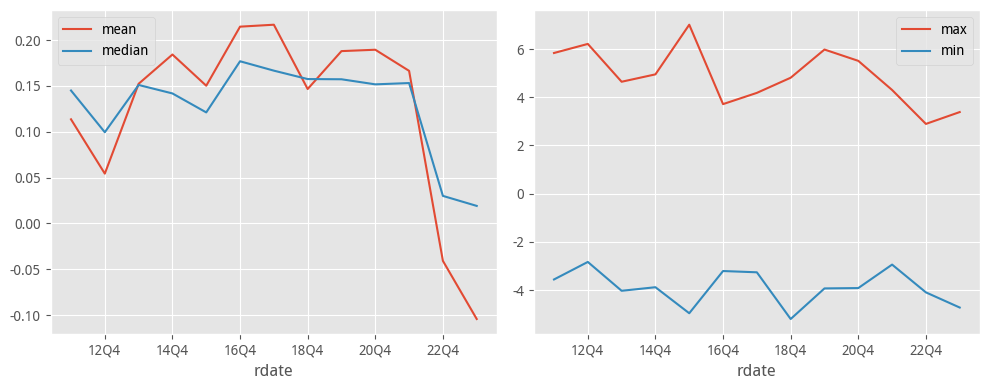

### 利润增长排名

利润增长的排名其实没有太大意义，因为一个公司很难保持长期高增长。大致看了一下，利润增长前20的榜单，超过260家，也就是说几乎没什么企业能长期在榜上的。

大致了解一下即可。

|  | cname | nums | tnums | pct |
| --- | --- | --- | --- | --- |
| 0 | 九鼎投资 | 7 | 14 | 0.500000 |
| 1 | 硅烷科技 | 7 | 10 | 0.700000 |
| 2 | 网宿科技 | 6 | 14 | 0.428571 |
| 3 | 诚志股份 | 6 | 14 | 0.428571 |
| 4 | 信达证券 | 6 | 14 | 0.428571 |
| 5 | 派林生物 | 6 | 14 | 0.428571 |
| 6 | 江山股份 | 6 | 14 | 0.428571 |
| 7 | 华洋赛车 | 6 | 11 | 0.545455 |
| 8 | 高测股份 | 6 | 11 | 0.545455 |
| 9 | 广汇能源 | 6 | 14 | 0.428571 |
| 10 | 天华新能 | 6 | 14 | 0.428571 |
| 11 | 明德生物 | 6 | 13 | 0.461538 |
| 12 | 平高电气 | 6 | 14 | 0.428571 |
| 13 | 国轩高科 | 5 | 14 | 0.357143 |
| 14 | 华鑫股份 | 5 | 14 | 0.357143 |
| 15 | 中航泰达 | 5 | 11 | 0.454545 |
| 16 | 东方盛虹 | 5 | 14 | 0.357143 |
| 17 | 湖南海利 | 5 | 14 | 0.357143 |
| 18 | 舍得酒业 | 5 | 14 | 0.357143 |
| 19 | 海油工程 | 5 | 14 | 0.357143 |

- 国轩高科，好象在哪里见过。肯定不是一家好公司。
- 硅烷科技好象在几个榜单中都见过。可能是家好公司。
- 信达证券。大金融也能连续高增长，不多见。

### 最近一年利润增长情况

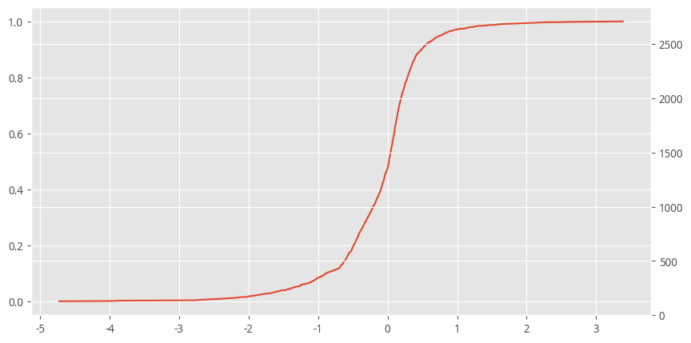

- 2023年，接近一半的上市公司没能实现利润增长。

### 夏普指数

- 夏普指数衡量利润增长的质量，比单纯看利润增长要好一点。
- 以下是近五年夏普指数平均后的前300排名。

1

[心脉医疗](https://data.eastmoney.com/stockdata/688016.html)

2

[航天电器](https://data.eastmoney.com/stockdata/002025.html)

3

[老百姓](https://data.eastmoney.com/stockdata/603883.html)

4

[益丰药房](https://data.eastmoney.com/stockdata/603939.html)

5

[亿田智能](https://data.eastmoney.com/stockdata/300911.html)

6

[新媒股份](https://data.eastmoney.com/stockdata/300770.html)

7

[松井股份](https://data.eastmoney.com/stockdata/688157.html)

8

[恩华药业](https://data.eastmoney.com/stockdata/002262.html)

9

[宁波银行](https://data.eastmoney.com/stockdata/002142.html)

10

[爱尔眼科](https://data.eastmoney.com/stockdata/300015.html)

11

[志邦家居](https://data.eastmoney.com/stockdata/603801.html)

12

[协创数据](https://data.eastmoney.com/stockdata/300857.html)

13

[南网能源](https://data.eastmoney.com/stockdata/003035.html)

14

[江苏金租](https://data.eastmoney.com/stockdata/600901.html)

15

[中科软](https://data.eastmoney.com/stockdata/603927.html)

16

[伟明环保](https://data.eastmoney.com/stockdata/603568.html)

17

[海天味业](https://data.eastmoney.com/stockdata/603288.html)

18

[味知香](https://data.eastmoney.com/stockdata/605089.html)

19

[地铁设计](https://data.eastmoney.com/stockdata/003013.html)

20

[华翔股份](https://data.eastmoney.com/stockdata/603112.html)

21

[恒盛能源](https://data.eastmoney.com/stockdata/605580.html)

22

[南京银行](https://data.eastmoney.com/stockdata/601009.html)

23

[斯达半导](https://data.eastmoney.com/stockdata/603290.html)

24

[蜂助手](https://data.eastmoney.com/stockdata/301382.html)

25

[贝特瑞](https://data.eastmoney.com/stockdata/835185.html)

26

[中际联合](https://data.eastmoney.com/stockdata/605305.html)

27

[亿联网络](https://data.eastmoney.com/stockdata/300628.html)

28

[浙江鼎力](https://data.eastmoney.com/stockdata/603338.html)

29

[派克新材](https://data.eastmoney.com/stockdata/605123.html)

30

[普利制药](https://data.eastmoney.com/stockdata/300630.html)

31

[大博医疗](https://data.eastmoney.com/stockdata/002901.html)

32

[安图生物](https://data.eastmoney.com/stockdata/603658.html)

33

[华东医药](https://data.eastmoney.com/stockdata/000963.html)

34

[一心堂](https://data.eastmoney.com/stockdata/002727.html)

35

[迈克生物](https://data.eastmoney.com/stockdata/300463.html)

36

[中熔电气](https://data.eastmoney.com/stockdata/301031.html)

37

[上海银行](https://data.eastmoney.com/stockdata/601229.html)

38

[德源药业](https://data.eastmoney.com/stockdata/832735.html)

39

[恒瑞医药](https://data.eastmoney.com/stockdata/600276.html)

40

[金博股份](https://data.eastmoney.com/stockdata/688598.html)

41

[中国核建](https://data.eastmoney.com/stockdata/601611.html)

42

[创识科技](https://data.eastmoney.com/stockdata/300941.html)

43

[海康威视](https://data.eastmoney.com/stockdata/002415.html)

44

[联环药业](https://data.eastmoney.com/stockdata/600513.html)

45

[紫金银行](https://data.eastmoney.com/stockdata/601860.html)

46

[蒙泰高新](https://data.eastmoney.com/stockdata/300876.html)

47

[特发服务](https://data.eastmoney.com/stockdata/300917.html)

48

[浙江美大](https://data.eastmoney.com/stockdata/002677.html)

49

[万孚生物](https://data.eastmoney.com/stockdata/300482.html)

50

[伟星新材](https://data.eastmoney.com/stockdata/002372.html)

51

[海天股份](https://data.eastmoney.com/stockdata/603759.html)

52

[苏文电能](https://data.eastmoney.com/stockdata/300982.html)

53

[晨光股份](https://data.eastmoney.com/stockdata/603899.html)

54

[铁科轨道](https://data.eastmoney.com/stockdata/688569.html)

55

[良信股份](https://data.eastmoney.com/stockdata/002706.html)

56

[利安隆](https://data.eastmoney.com/stockdata/300596.html)

57

[健帆生物](https://data.eastmoney.com/stockdata/300529.html)

58

[嘉友国际](https://data.eastmoney.com/stockdata/603871.html)

59

[中航光电](https://data.eastmoney.com/stockdata/002179.html)

60

[呈和科技](https://data.eastmoney.com/stockdata/688625.html)

61

[博瑞医药](https://data.eastmoney.com/stockdata/688166.html)

62

[片仔癀](https://data.eastmoney.com/stockdata/600436.html)

63

[星宇股份](https://data.eastmoney.com/stockdata/601799.html)

64

[中瓷电子](https://data.eastmoney.com/stockdata/003031.html)

65

[景嘉微](https://data.eastmoney.com/stockdata/300474.html)

66

[豪悦护理](https://data.eastmoney.com/stockdata/605009.html)

67

[三人行](https://data.eastmoney.com/stockdata/605168.html)

68

[瑞丰新材](https://data.eastmoney.com/stockdata/300910.html)

69

[玉禾田](https://data.eastmoney.com/stockdata/300815.html)

70

[菲利华](https://data.eastmoney.com/stockdata/300395.html)

71

[安井食品](https://data.eastmoney.com/stockdata/603345.html)

72

[柳药集团](https://data.eastmoney.com/stockdata/603368.html)

73

[江苏银行](https://data.eastmoney.com/stockdata/600919.html)

74

[青鸟消防](https://data.eastmoney.com/stockdata/002960.html)

75

[胜宏科技](https://data.eastmoney.com/stockdata/300476.html)

76

[中国建筑](https://data.eastmoney.com/stockdata/601668.html)

77

[贵阳银行](https://data.eastmoney.com/stockdata/601997.html)

78

[招商银行](https://data.eastmoney.com/stockdata/600036.html)

79

[苏试试验](https://data.eastmoney.com/stockdata/300416.html)

80

[威胜信息](https://data.eastmoney.com/stockdata/688100.html)

81

[中文传媒](https://data.eastmoney.com/stockdata/600373.html)

82

[西大门](https://data.eastmoney.com/stockdata/605155.html)

83

[坤恒顺维](https://data.eastmoney.com/stockdata/688283.html)

84

[泛微网络](https://data.eastmoney.com/stockdata/603039.html)

85

[立讯精密](https://data.eastmoney.com/stockdata/002475.html)

86

[中国科传](https://data.eastmoney.com/stockdata/601858.html)

87

[比音勒芬](https://data.eastmoney.com/stockdata/002832.html)

88

[武汉蓝电](https://data.eastmoney.com/stockdata/830779.html)

89

[康龙化成](https://data.eastmoney.com/stockdata/300759.html)

90

[奕瑞科技](https://data.eastmoney.com/stockdata/688301.html)

91

[长沙银行](https://data.eastmoney.com/stockdata/601577.html)

92

[凌霄泵业](https://data.eastmoney.com/stockdata/002884.html)

93

[中国黄金](https://data.eastmoney.com/stockdata/600916.html)

94

[柏楚电子](https://data.eastmoney.com/stockdata/688188.html)

95

[京华激光](https://data.eastmoney.com/stockdata/603607.html)

96

[快克智能](https://data.eastmoney.com/stockdata/603203.html)

97

[海昇药业](https://data.eastmoney.com/stockdata/870656.html)

98

[景旺电子](https://data.eastmoney.com/stockdata/603228.html)

99

[京新药业](https://data.eastmoney.com/stockdata/002020.html)

100

[思泰克](https://data.eastmoney.com/stockdata/301568.html)

101

[国检集团](https://data.eastmoney.com/stockdata/603060.html)

102

[曙光数创](https://data.eastmoney.com/stockdata/872808.html)

103

[凯莱英](https://data.eastmoney.com/stockdata/002821.html)

104

[盛航股份](https://data.eastmoney.com/stockdata/001205.html)

105

[中国中免](https://data.eastmoney.com/stockdata/601888.html)

106

[无锡鼎邦](https://data.eastmoney.com/stockdata/872931.html)

107

[华生科技](https://data.eastmoney.com/stockdata/605180.html)

108

[捷佳伟创](https://data.eastmoney.com/stockdata/300724.html)

109

[凯立新材](https://data.eastmoney.com/stockdata/688269.html)

110

[重庆银行](https://data.eastmoney.com/stockdata/601963.html)

111

[华设集团](https://data.eastmoney.com/stockdata/603018.html)

112

[三峰环境](https://data.eastmoney.com/stockdata/601827.html)

113

[正海生物](https://data.eastmoney.com/stockdata/300653.html)

114

[泰格医药](https://data.eastmoney.com/stockdata/300347.html)

115

[胜蓝股份](https://data.eastmoney.com/stockdata/300843.html)

116

[三友联众](https://data.eastmoney.com/stockdata/300932.html)

117

[迪瑞医疗](https://data.eastmoney.com/stockdata/300396.html)

118

[沪农商行](https://data.eastmoney.com/stockdata/601825.html)

119

[祥源新材](https://data.eastmoney.com/stockdata/300980.html)

120

[我武生物](https://data.eastmoney.com/stockdata/300357.html)

121

[欧派家居](https://data.eastmoney.com/stockdata/603833.html)

122

[国恩股份](https://data.eastmoney.com/stockdata/002768.html)

123

[众智科技](https://data.eastmoney.com/stockdata/301361.html)

124

[华峰测控](https://data.eastmoney.com/stockdata/688200.html)

125

[火炬电子](https://data.eastmoney.com/stockdata/603678.html)

126

[金牌家居](https://data.eastmoney.com/stockdata/603180.html)

127

[德赛电池](https://data.eastmoney.com/stockdata/000049.html)

128

[老板电器](https://data.eastmoney.com/stockdata/002508.html)

129

[苏轴股份](https://data.eastmoney.com/stockdata/430418.html)

130

[视源股份](https://data.eastmoney.com/stockdata/002841.html)

131

[唐山港](https://data.eastmoney.com/stockdata/601000.html)

132

[北方国际](https://data.eastmoney.com/stockdata/000065.html)

133

[昭衍新药](https://data.eastmoney.com/stockdata/603127.html)

134

[通策医疗](https://data.eastmoney.com/stockdata/600763.html)

135

[宏川智慧](https://data.eastmoney.com/stockdata/002930.html)

136

[东方雨虹](https://data.eastmoney.com/stockdata/002271.html)

137

[兴瑞科技](https://data.eastmoney.com/stockdata/002937.html)

138

[青岛港](https://data.eastmoney.com/stockdata/601298.html)

139

[南大环境](https://data.eastmoney.com/stockdata/300864.html)

140

[大参林](https://data.eastmoney.com/stockdata/603233.html)

141

[桃李面包](https://data.eastmoney.com/stockdata/603866.html)

142

[朗特智能](https://data.eastmoney.com/stockdata/300916.html)

143

[三星新材](https://data.eastmoney.com/stockdata/603578.html)

144

[北京银行](https://data.eastmoney.com/stockdata/601169.html)

145

[中控技术](https://data.eastmoney.com/stockdata/688777.html)

146

[锋尚文化](https://data.eastmoney.com/stockdata/300860.html)

147

[广道数字](https://data.eastmoney.com/stockdata/839680.html)

148

[联瑞新材](https://data.eastmoney.com/stockdata/688300.html)

149

[森麒麟](https://data.eastmoney.com/stockdata/002984.html)

150

[青岛银行](https://data.eastmoney.com/stockdata/002948.html)

151

[南方传媒](https://data.eastmoney.com/stockdata/601900.html)

152

[杭叉集团](https://data.eastmoney.com/stockdata/603298.html)

153

[启明星辰](https://data.eastmoney.com/stockdata/002439.html)

154

[天健集团](https://data.eastmoney.com/stockdata/000090.html)

155

[盛视科技](https://data.eastmoney.com/stockdata/002990.html)

156

[崧盛股份](https://data.eastmoney.com/stockdata/301002.html)

157

[美瑞新材](https://data.eastmoney.com/stockdata/300848.html)

158

[博思软件](https://data.eastmoney.com/stockdata/300525.html)

159

[法本信息](https://data.eastmoney.com/stockdata/300925.html)

160

[新产业](https://data.eastmoney.com/stockdata/300832.html)

161

[迪安诊断](https://data.eastmoney.com/stockdata/300244.html)

162

[好太太](https://data.eastmoney.com/stockdata/603848.html)

163

[今世缘](https://data.eastmoney.com/stockdata/603369.html)

164

[常熟银行](https://data.eastmoney.com/stockdata/601128.html)

165

[寿仙谷](https://data.eastmoney.com/stockdata/603896.html)

166

[天合光能](https://data.eastmoney.com/stockdata/688599.html)

167

[键凯科技](https://data.eastmoney.com/stockdata/688356.html)

168

[兴业银行](https://data.eastmoney.com/stockdata/601166.html)

169

[杭州银行](https://data.eastmoney.com/stockdata/600926.html)

170

[久远银海](https://data.eastmoney.com/stockdata/002777.html)

171

[祖名股份](https://data.eastmoney.com/stockdata/003030.html)

172

[广咨国际](https://data.eastmoney.com/stockdata/836892.html)

173

[南凌科技](https://data.eastmoney.com/stockdata/300921.html)

174

[三元生物](https://data.eastmoney.com/stockdata/301206.html)

175

[光弘科技](https://data.eastmoney.com/stockdata/300735.html)

176

[昊帆生物](https://data.eastmoney.com/stockdata/301393.html)

177

[中环环保](https://data.eastmoney.com/stockdata/300692.html)

178

[华瓷股份](https://data.eastmoney.com/stockdata/001216.html)

179

[华旺科技](https://data.eastmoney.com/stockdata/605377.html)

180

[海晨股份](https://data.eastmoney.com/stockdata/300873.html)

181

[海昌新材](https://data.eastmoney.com/stockdata/300885.html)

182

[密尔克卫](https://data.eastmoney.com/stockdata/603713.html)

183

[景津装备](https://data.eastmoney.com/stockdata/603279.html)

184

[中农立华](https://data.eastmoney.com/stockdata/603970.html)

185

[长春高新](https://data.eastmoney.com/stockdata/000661.html)

186

[贵州茅台](https://data.eastmoney.com/stockdata/600519.html)

187

[奇正藏药](https://data.eastmoney.com/stockdata/002287.html)

188

[福立旺](https://data.eastmoney.com/stockdata/688678.html)

189

[上海医药](https://data.eastmoney.com/stockdata/601607.html)

190

[广州酒家](https://data.eastmoney.com/stockdata/603043.html)

191

[秋田微](https://data.eastmoney.com/stockdata/300939.html)

192

[仁信新材](https://data.eastmoney.com/stockdata/301395.html)

193

[鹭燕医药](https://data.eastmoney.com/stockdata/002788.html)

194

[吉冈精密](https://data.eastmoney.com/stockdata/836720.html)

195

[贵州三力](https://data.eastmoney.com/stockdata/603439.html)

196

[奥泰生物](https://data.eastmoney.com/stockdata/688606.html)

197

[维海德](https://data.eastmoney.com/stockdata/301318.html)

198

[中天火箭](https://data.eastmoney.com/stockdata/003009.html)

199

[山河药辅](https://data.eastmoney.com/stockdata/300452.html)

200

[兴蓉环境](https://data.eastmoney.com/stockdata/000598.html)

201

[诺力股份](https://data.eastmoney.com/stockdata/603611.html)

202

[平安银行](https://data.eastmoney.com/stockdata/000001.html)

203

[银信科技](https://data.eastmoney.com/stockdata/300231.html)

204

[艾华集团](https://data.eastmoney.com/stockdata/603989.html)

205

[凌玮科技](https://data.eastmoney.com/stockdata/301373.html)

206

[农业银行](https://data.eastmoney.com/stockdata/601288.html)

207

[北摩高科](https://data.eastmoney.com/stockdata/002985.html)

208

[中密控股](https://data.eastmoney.com/stockdata/300470.html)

209

[天孚通信](https://data.eastmoney.com/stockdata/300394.html)

210

[建设银行](https://data.eastmoney.com/stockdata/601939.html)

211

[葵花药业](https://data.eastmoney.com/stockdata/002737.html)

212

[璞泰来](https://data.eastmoney.com/stockdata/603659.html)

213

[金徽酒](https://data.eastmoney.com/stockdata/603919.html)

214

[东南电子](https://data.eastmoney.com/stockdata/301359.html)

215

[中国平安](https://data.eastmoney.com/stockdata/601318.html)

216

[信捷电气](https://data.eastmoney.com/stockdata/603416.html)

217

[诚意药业](https://data.eastmoney.com/stockdata/603811.html)

218

[甘源食品](https://data.eastmoney.com/stockdata/002991.html)

219

[大华股份](https://data.eastmoney.com/stockdata/002236.html)

220

[德才股份](https://data.eastmoney.com/stockdata/605287.html)

221

[西安银行](https://data.eastmoney.com/stockdata/600928.html)

222

[显盈科技](https://data.eastmoney.com/stockdata/301067.html)

223

[振华科技](https://data.eastmoney.com/stockdata/000733.html)

224

[同仁堂](https://data.eastmoney.com/stockdata/600085.html)

225

[润达医疗](https://data.eastmoney.com/stockdata/603108.html)

226

[睿创微纳](https://data.eastmoney.com/stockdata/688002.html)

227

[苏垦农发](https://data.eastmoney.com/stockdata/601952.html)

228

[恩捷股份](https://data.eastmoney.com/stockdata/002812.html)

229

[浙商银行](https://data.eastmoney.com/stockdata/601916.html)

230

[普门科技](https://data.eastmoney.com/stockdata/688389.html)

231

[欧普康视](https://data.eastmoney.com/stockdata/300595.html)

232

[捷安高科](https://data.eastmoney.com/stockdata/300845.html)

233

[驰诚股份](https://data.eastmoney.com/stockdata/834407.html)

234

[中国银行](https://data.eastmoney.com/stockdata/601988.html)

235

[涪陵榨菜](https://data.eastmoney.com/stockdata/002507.html)

236

[周大生](https://data.eastmoney.com/stockdata/002867.html)

237

[星帅尔](https://data.eastmoney.com/stockdata/002860.html)

238

[弘亚数控](https://data.eastmoney.com/stockdata/002833.html)

239

[中国外运](https://data.eastmoney.com/stockdata/601598.html)

240

[国药一致](https://data.eastmoney.com/stockdata/000028.html)

241

[迅安科技](https://data.eastmoney.com/stockdata/834950.html)

242

[凯德石英](https://data.eastmoney.com/stockdata/835179.html)

243

[中国中铁](https://data.eastmoney.com/stockdata/601390.html)

244

[艾隆科技](https://data.eastmoney.com/stockdata/688329.html)

245

[福蓉科技](https://data.eastmoney.com/stockdata/603327.html)

246

[凯普生物](https://data.eastmoney.com/stockdata/300639.html)

247

[京北方](https://data.eastmoney.com/stockdata/002987.html)

248

[广和通](https://data.eastmoney.com/stockdata/300638.html)

249

[思泉新材](https://data.eastmoney.com/stockdata/301489.html)

250

[盖世食品](https://data.eastmoney.com/stockdata/836826.html)

251

[科锐国际](https://data.eastmoney.com/stockdata/300662.html)

252

[浪潮信息](https://data.eastmoney.com/stockdata/000977.html)

253

[润建股份](https://data.eastmoney.com/stockdata/002929.html)

254

[高铁电气](https://data.eastmoney.com/stockdata/688285.html)

255

[新中港](https://data.eastmoney.com/stockdata/605162.html)

256

[伟思医疗](https://data.eastmoney.com/stockdata/688580.html)

257

[先导智能](https://data.eastmoney.com/stockdata/300450.html)

258

[透景生命](https://data.eastmoney.com/stockdata/300642.html)

259

[沪江材料](https://data.eastmoney.com/stockdata/870204.html)

260

[万胜智能](https://data.eastmoney.com/stockdata/300882.html)

261

[杭可科技](https://data.eastmoney.com/stockdata/688006.html)

262

[中国铁建](https://data.eastmoney.com/stockdata/601186.html)

263

[公牛集团](https://data.eastmoney.com/stockdata/603195.html)

264

[索菲亚](https://data.eastmoney.com/stockdata/002572.html)

265

[威贸电子](https://data.eastmoney.com/stockdata/833346.html)

266

[精测电子](https://data.eastmoney.com/stockdata/300567.html)

267

[海尔智家](https://data.eastmoney.com/stockdata/600690.html)

268

[海容冷链](https://data.eastmoney.com/stockdata/603187.html)

269

[鱼跃医疗](https://data.eastmoney.com/stockdata/002223.html)

270

[深圳燃气](https://data.eastmoney.com/stockdata/601139.html)

271

[迦南智能](https://data.eastmoney.com/stockdata/300880.html)

272

[龙磁科技](https://data.eastmoney.com/stockdata/300835.html)

273

[苑东生物](https://data.eastmoney.com/stockdata/688513.html)

274

[云里物里](https://data.eastmoney.com/stockdata/872374.html)

275

[华康股份](https://data.eastmoney.com/stockdata/605077.html)

276

[嘉戎技术](https://data.eastmoney.com/stockdata/301148.html)

277

[东方电子](https://data.eastmoney.com/stockdata/000682.html)

278

[捷昌驱动](https://data.eastmoney.com/stockdata/603583.html)

279

[科大讯飞](https://data.eastmoney.com/stockdata/002230.html)

280

[皓元医药](https://data.eastmoney.com/stockdata/688131.html)

281

[天元宠物](https://data.eastmoney.com/stockdata/301335.html)

282

[银都股份](https://data.eastmoney.com/stockdata/603277.html)

283

[太极股份](https://data.eastmoney.com/stockdata/002368.html)

284

[宁新新材](https://data.eastmoney.com/stockdata/839719.html)

285

[吉贝尔](https://data.eastmoney.com/stockdata/688566.html)

286

[德业股份](https://data.eastmoney.com/stockdata/605117.html)

287

[圣邦股份](https://data.eastmoney.com/stockdata/300661.html)

288

[西上海](https://data.eastmoney.com/stockdata/605151.html)

289

[昂利康](https://data.eastmoney.com/stockdata/002940.html)

290

[伯特利](https://data.eastmoney.com/stockdata/603596.html)

291

[渝农商行](https://data.eastmoney.com/stockdata/601077.html)

292

[捷捷微电](https://data.eastmoney.com/stockdata/300623.html)

293

[大丰实业](https://data.eastmoney.com/stockdata/603081.html)

294

[光大银行](https://data.eastmoney.com/stockdata/601818.html)

295

[科思股份](https://data.eastmoney.com/stockdata/300856.html)

296

[交通银行](https://data.eastmoney.com/stockdata/601328.html)

297

[中信出版](https://data.eastmoney.com/stockdata/300788.html)

298

[茂莱光学](https://data.eastmoney.com/stockdata/688502.html)

299

[保利发展](https://data.eastmoney.com/stockdata/600048.html)

300

[永安期货](https://data.eastmoney.com/stockdata/600927.html)

## 利润金额和利润增长

- 利润总额曾经进入过前300,同时利润增长夏普指数近五年平均也进入前300
- 大金融不管怎么排，总能占到三分之一。

```
total: 67 | banks: 24
```

13

[海天味业](https://data.eastmoney.com/stockdata/603288.html)

2.41

13

[海尔智家](https://data.eastmoney.com/stockdata/600690.html)

1.00

13

[恒瑞医药](https://data.eastmoney.com/stockdata/600276.html)

1.89

13

[海康威视](https://data.eastmoney.com/stockdata/002415.html)

1.86

13

[中国建筑](https://data.eastmoney.com/stockdata/601668.html)

1.57

10

[青岛港](https://data.eastmoney.com/stockdata/601298.html)

1.29

13

[保利发展](https://data.eastmoney.com/stockdata/600048.html)

0.96

13

[中国外运](https://data.eastmoney.com/stockdata/601598.html)

1.04

13

[中国中铁](https://data.eastmoney.com/stockdata/601390.html)

1.03

13

[中国铁建](https://data.eastmoney.com/stockdata/601186.html)

1.01

13

[上海医药](https://data.eastmoney.com/stockdata/601607.html)

1.14

13

[中国平安](https://data.eastmoney.com/stockdata/601318.html)

1.09

13

[贵州茅台](https://data.eastmoney.com/stockdata/600519.html)

1.15

13

[中国中免](https://data.eastmoney.com/stockdata/601888.html)

1.40

8

[公牛集团](https://data.eastmoney.com/stockdata/603195.html)

1.00

13

[大华股份](https://data.eastmoney.com/stockdata/002236.html)

1.08

13

[华东医药](https://data.eastmoney.com/stockdata/000963.html)

2.00

13

[唐山港](https://data.eastmoney.com/stockdata/601000.html)

1.32

13

[立讯精密](https://data.eastmoney.com/stockdata/002475.html)

1.52

13

[中文传媒](https://data.eastmoney.com/stockdata/600373.html)

1.54

12

[欧派家居](https://data.eastmoney.com/stockdata/603833.html)

1.35

13

[东方雨虹](https://data.eastmoney.com/stockdata/002271.html)

1.30

13

[长春高新](https://data.eastmoney.com/stockdata/000661.html)

1.15

12

[今世缘](https://data.eastmoney.com/stockdata/603369.html)

1.21

13

[老板电器](https://data.eastmoney.com/stockdata/002508.html)

1.32

13

[江苏金租](https://data.eastmoney.com/stockdata/600901.html)

2.61

7

[天合光能](https://data.eastmoney.com/stockdata/688599.html)

1.20

12

[恩捷股份](https://data.eastmoney.com/stockdata/002812.html)

1.07

13

[爱尔眼科](https://data.eastmoney.com/stockdata/300015.html)

2.95

13

[片仔癀](https://data.eastmoney.com/stockdata/600436.html)

1.67

12

[凯莱英](https://data.eastmoney.com/stockdata/002821.html)

1.42

12

[视源股份](https://data.eastmoney.com/stockdata/002841.html)

1.32

13

[国药一致](https://data.eastmoney.com/stockdata/000028.html)

1.04

13

[同仁堂](https://data.eastmoney.com/stockdata/600085.html)

1.08

13

[振华科技](https://data.eastmoney.com/stockdata/000733.html)

1.08

13

[中航光电](https://data.eastmoney.com/stockdata/002179.html)

1.69

13

[兴蓉环境](https://data.eastmoney.com/stockdata/000598.html)

1.11

10

[璞泰来](https://data.eastmoney.com/stockdata/603659.html)

1.10

12

[中国核建](https://data.eastmoney.com/stockdata/601611.html)

1.87

12

[先导智能](https://data.eastmoney.com/stockdata/300450.html)

1.01

13

[泰格医药](https://data.eastmoney.com/stockdata/300347.html)

1.37

13

[深圳燃气](https://data.eastmoney.com/stockdata/601139.html)

1.00

13

[鱼跃医疗](https://data.eastmoney.com/stockdata/002223.html)

1.00